# Computational Statistics 11.2: Time

## Time (Optional)

### Overview

This lesson introduces time series modeling.

### Objectives

After completing this module, students should be able to:

1. Difference time series data to make it stationary.
2. Use PACF and ACF functions to assess AR and MA models.
3. Estimate ARIMA models using R and predict new values.

### Readings

Lander, Chapter 24.1

## Time series

**Definition:** A **time series** or temporal data is a variable for which we collect information at different moments in time ($t$).

- Generally we use the subscript $t$ to indicate that a variable is measured in different periods, e.g. $x_{t}$, $y_{t}$, etc. $t$ indicates the time in which the variable was measured, generally $t$ is measured in discrete intervals, like days, months, years, etc.
- Then, if $t$ means years, $x_{1990}$ is the value of variable $x$ in $1990$ and $x_{2000}$ is the value of $x$ in the year $2000$.
- We refer to the previous value $x_{t}$ as $x_{t-1}$, and the following or future value as $x_{t+1}$. The change temporal change in variable $x$ can be represented with is $\Delta x_{t} = x_{t}-x_{t-1}$.

Time series allow us to see how a variable evolves over time, it allow us to answer research questions about temporal effects. For example,

1. What’s the long-term effect on an individual’s health status of smoking cigarettes?
2. What’s the short-term and long-term effect on unemployment of a reduction of income taxes?

Not only time series allow us to introduce time as a new dimension to test hypothesis. It also, allow us to make predictions about the future. For example,

1. What’s going the be the price of a specific stock three months from now?
2. What’s the expected demand for a product in the next ten years?

As you can see, this are very ambitious questions and we’ll rarely completely succeed in answering them without a little bit of luck. Temporal data is some of the trickiest to deal with, and is something we can only briefly discuss here. To be honest, the main purpose of this lesson is just to illustrate how tricky it is and not to teach you how to master the different methods/techniques. **You should be very careful when making inferences from temporal data until you’ve taken an entire course on the subject**.

### The problem with time

The main problem with time is that in the multiple regression model we have implicitly assumed that observations are independent of each other; with time, almost by definition an observation at time $t$ is likely to be correlated with the observation at time $t-1$. Formally,

$$\text{cor}(x_{t}, x_{t-1}) \neq 0$$

Thus, if we define variables $x_{t}$ and $x_{t-1}$, they are likely going to be correlated with each other and with $y_{t}$ – this violates the exogeneity assumption –.

The variables $x_{t}$ and $x_{t-1}$ are correlated because most temporal variables have what we call a **time trend**, variables that tend to generally increase or decrease over time. Then, if a variable is growing over time, then the future value of it are going to be positively correlated with the present value. Also, if a variable is shrinking over time, then the future value of is negatively correlated with the present value.

### Spurious temporal relations (1/2)

Furthermore, if you seek to find the effect of $x$ on $y$ and both share an overall trend (e.g., both go up historically), then you will capture an spurious relationship if you regress $y$ on $x$ due only to this shared trend, and not any actual causal effect of $x$ on $y$. Formally, let $z = \text{time}$ then,

$$\text{cor}(x, z) \neq 0$$
and,
$$\text{cor}(y, z) \neq 0$$

This implies that time is creating an artificial relation between $x$ and $y$.

```r
#install.packages("WDI")
library(WDI) # This package allow you to download data from the World Bank
             # is a great source if you need quick macroeconomic statistics
             # for different countries.
gdp <- WDI(country=c("US", "CA", "UK", "AUS", "ES", "JP"), indicator="NY.GDP.PCAP.CD", start=1960, end=2018)
colnames(gdp)[3] <- "PerCapGDP"
```

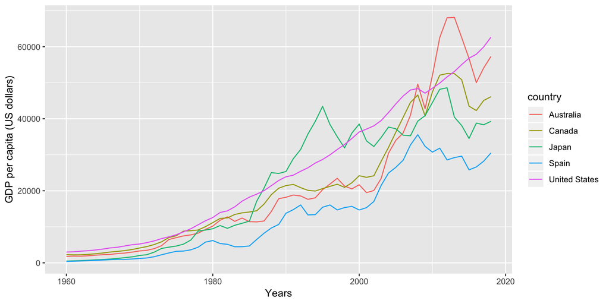

```r
library(ggplot2)
ggplot(gdp,aes(year,PerCapGDP,color=country)) + geom_line() + ylab("GDP per capita (US dollars)") + xlab("Years")
```

Note how all the countries GPD per capita increase over time, even if there is some slow-downs in some periods (See Japan after 1995). This common (positive) trend will create an artificial relation between the GPD per capita of all the countries. We can take any two countries and run a linear regression and we are guaranteed to find a statistically significant parameter and a very high $R^2$:

For example, the GDP per capita in the US as a function of GDP per capita in Spain

```r
gdpUS <- gdp$PerCapGDP[gdp$country=="United States"]
gdpES <- gdp$PerCapGDP[gdp$country=="Spain"]
suppressMessages(library(stargazer))
stargazer(lm(gdpUS~gdpES),
          header = FALSE,
          type = "html")
```

|  | *Dependent variable:* |
| --- | --- |
|  | gdpUS |
| gdpES | 1.597*** |
|  | (0.056) |
| Constant | 4,821.013*** |
|  | (953.500) |
| Observations | 59 |
| R<sup>2</sup> | 0.935 |
| Adjusted R<sup>2</sup> | 0.933 |
| Residual Std. Error | 4,786.256 (df = 57) |
| F Statistic | 814.512*** (df = 1; 57) |
| *Note:* | p<0.1; p<0.05; p<0.01 |

- Vaccines cause autism.
- Seat belts usage cause cancer.
- Smartphones cause cancer.
- [insert new trend] cause cancer.
- Universal Health Care breeds terrorism.
- Religiosity reduce educational attainment.

You can see how statistics can be abused – specially with the uninitiated –. Anything with a common time trend will be correlated, and it is a bad practice to ignore the fact that this relations are spurious to push a specific agenda.

This problem, also has the unintended consequence that people start to lose faith in statistics (and its practitioners), and data driven arguments become less convincing after people know that data can be manipulated in this way.

### Spurious temporal relations (2/2)

You may think, well if there is a spurious relation between the GDP per capita of Spain and the US, we should be able to disentangle the causal pathways by adding the relation that is causing the spurious relation: time. Then, let’s add time to the regression and see what happens.

```r
time <- 1960:2018
stargazer(lm(gdpUS ~ gdpES + time),
          header = FALSE,
          type = "html")
```

|  | *Dependent variable:* |
| --- | --- |
|  | gdpUS |
| gdpES | 0.560*** |
|  | (0.096) |
| time | -716.216*** |
|  | (62.963) |
| Constant | 1,442,749.000*** |
|  | (126,411.000) |
| Observations | 59 |
| R<sup>2</sup> | 0.980 |
| Adjusted R<sup>2</sup> | 0.980 |
| Residual Std. Error | 2,653.910 (df = 56) |
| F Statistic | 1,389.303*** (df = 2; 56) |
| *Note:* | p<0.1; p<0.05; p<0.01 |

No luck! the parameter is still different than zero. Which is not consistent with the idea of a spurious relation – ideally, after controlling for $z$ we should be able to estimate the actual relation between $x$ and $y4 –. The reason for that is time cannot be modeled just like any other omitted variable. In the following slides we’ll learn how to capture the actual effect between two time series.

## Time Differences (1/3)

Note that the **problem** is that the trend in the data is causing
$$\text{cor}(x, \text{Time}) \neq 0$$
and
$$\text{cor}(y, \text{Time}) \neq 0$$

Then, we need to find a way of working with $x$ and $y$ that ignores the time trend.

We need to “detrend” the data – remove the overall temporal trend –, $x$ and $y$ need to be independent of time, i.e. tendencies up or down from one data point to the next. The key insight is that we are fundamentally interested not in the effect of $x$ on $y$ if they are both trending up (or going up and down seasonally), but rather the effect of the *change* in $x$ on the *change* in $y$.

That is, if we think a that a “shock” to $x$ (a short-term change in $x$) has a short-term effect on $y$, then even if they are both trending up (or both going up and down seasonally), we would expect a change in $x$ to have an effect on $y$, even as both are generally trending upward. To model this, we once again do the trick of transforming the variables – this time, by “differentiating” or calculating the time difference –.

What this means is that instead of looking at $y$ as a function of $x$, we look at the difference $\Delta y_{t} = y_t - y_{t-1}$ as function of $\Delta x_{t} = x_t - x_{t-1}$. That is, if the data is yearly, we look at the year-to-year change in $y$ on the year-to-year change in $x$. If $y$ is {1, 3, 2, 5}, then the first differences are {3 -1 = 2, 2-3 = -1, 5 - 2 =3}. If we do this, we will tend to see the series flatten out, and it will look non-trending.

### Time Differences (2/3)

In `R` we can generate this first difference automatically via the `diff` function, or manually by just subtracting each $y_{t-1}$ from $y_{t}$.

To do it automatically, first we have to code the data as a time series (`ts`) so that `R` understands that we are now dealing with temporal data:

```r
gdpUS <- rev(gdpUS) # This will sort the time trend from present to past
                    # By default, the WDI package displays the most
                    # recent data at the top.
ts_gdpUS <- ts(gdpUS, start=1960, end=2018)
```

Then we can generate the difference using `diff` or do it manually:

```r
us.d1 <- diff(ts_gdpUS) # automatic
```

We can also do it manually

```r
lag0 <- ts_gdpUS[2:(length(ts_gdpUS) - 0)] # the original series
lag1 <- ts_gdpUS[1:(length(ts_gdpUS) - 1)] # the series "lagged" or offset by one year
ts_gdpUS.d1a <- lag0 - lag1
cor(us.d1, ts_gdpUS.d1a) # This should be 1 if the two series are the same
```

```
[1] 1
```

(Note the use of the term “lag” – the series $y_{t-1}$ is a whole sequence of $y$ values, just offset by 1: if the first value in $y_t$ is for 2018, the first value in $y_{t-1}$ is for 2017; if the second $y_t$ is for 2009, the second value in $y_{t-1}$ is for 2008; and so on. If you regress the $y_t$ vector on the $y_{t-1}$ vector, you are regressing each year’s GDP per capita on the previous year’s GDP per capita.)

### Time Differences (3/3)

The goal is to make new series “stationary” – that is, whether it is no longer trending up or down –. We can plot it and see:

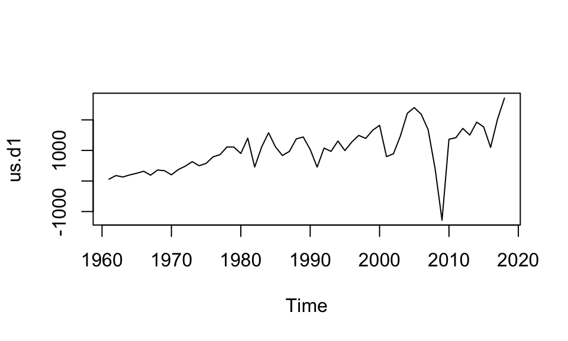

```r
plot(us.d1)
```

Hmmm – that still looks like it’s going up overall if we ignore the big recession in 2008. If it is, we can difference it a second time, and see whether that fixes it. But how do we know when to stop? Luckily there are tests for whether a sequence is stationary, and we can just keep differentiating it until it is. But rather than do that manually, we can of course just use `R` to tell us, via the `ndiffs` function in the `forecast` package:

```r
#install.packages("forecast")
library(forecast)
ndiffs(ts_gdpUS)
```

```
[1] 2
```

That tells us the answer is 2. So our stationary version is

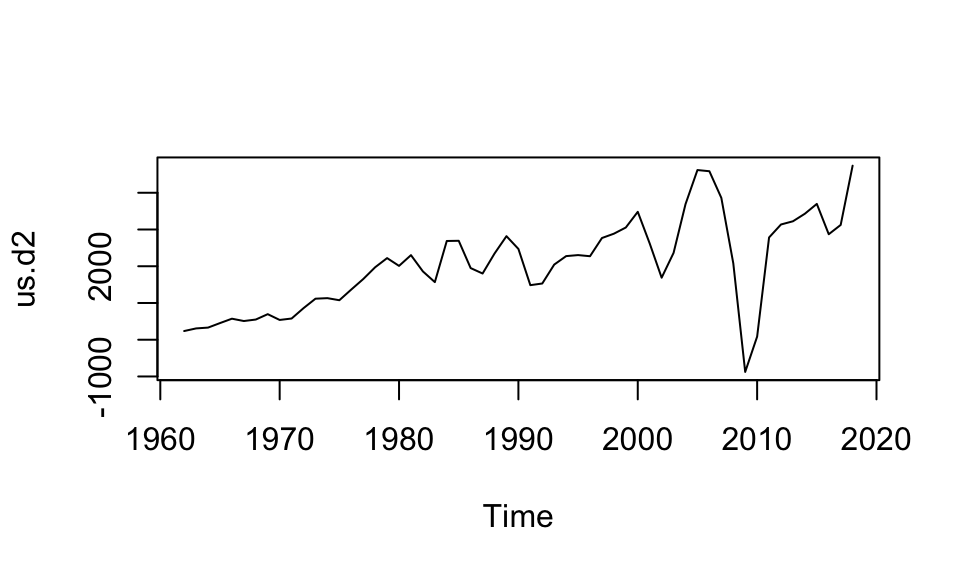

```r
us.d2 <- diff(ts_gdpUS,2)
plot(us.d2)
```

It looks very similar to the previous graph, but at least we know it pass the stationarity test.

## Regression

At this point, we could plunge directly into regression, and look at the relation between the differentiated GDP variables to see whether, after detrending, these two time series are still related – that is, whether they bounce up and down together independent of their shared tendency to go up over time.

```r
es <- rev(gdpES)
es <- ts(es,start=1960,end=2018)
ndiffs(es)
```

[1] 1

```r
es.d1 <- diff(es,1)
es.d1 <- es.d1[-length(es.d1)] # Dropping last observation
stargazer(lm(us.d2 ~ es.d1),
          header = FALSE,
          type = "html")
```

|  | *Dependent variable:* |
| --- | --- |
|  | us.d2 |
| es.d1 | 0.129 |
|  | (0.104) |
| Constant | 1,980.971*** |
|  | (170.634) |
| Observations | 57 |
| R<sup>2</sup> | 0.027 |
| Adjusted R<sup>2</sup> | 0.009 |
| Residual Std. Error | 1,229.899 (df = 55) |
| F Statistic | 1.530 (df = 1; 55) |
| *Note:* | p<0.1; p<0.05; p<0.01 |

So after differencing, we cannot reject the null that the Spanish GDP per capita is not related to the US GDP per capita at $\alpha = 0.95$. We can try it with the GDP of other economies that may be more relevant for the US, for example Canada, China, Mexico, etc.

```r
gdp <- WDI(country="all", indicator="NY.GDP.PCAP.CD", start=1960, end=2018)
gdpCH <- gdp$NY.GDP.PCAP.CD[gdp$country=="China"]
ch <- rev(gdpCH)
ch <- ts(ch,start=1960,end=2018)
ndiffs(ch)
```

[1] 2

```r
ch.d2 <- diff(ch,2)
stargazer(lm(us.d2 ~ ch.d2),
          header = FALSE,
          type = "html")
```

|  | *Dependent variable:* |
| --- | --- |
|  | us.d2 |
| ch.d2 | 0.956*** |
|  | (0.295) |
| Constant | 1,735.812*** |
|  | (178.643) |
| Observations | 57 |
| R<sup>2</sup> | 0.161 |
| Adjusted R<sup>2</sup> | 0.145 |
| Residual Std. Error | 1,142.419 (df = 55) |
| F Statistic | 10.519*** (df = 1; 55) |
| *Note:* | p<0.1; p<0.05; p<0.01 |

A very careful interpretation of this results would be, for the US economy the Chinese economy is more important than the Spanish economy. At this stage, before you take an entire course in time series, this very conservative statement is appropriate.

## Auto-correlation

After considering time, $y$ is not just a function of $x$: $y$ is also a function of its own past values, even after differencing. A shock to $y$ can persist into the next period, and the one after that, and so on. For instance, the “oil shock” in the mid-70s lead the US economy into a recession, and even when the cause of the shock (the oil price hike) disappeared, it took a long-time for the effects to work out of the system. So we really have to control for past values of $y$, even when regressing $y$ on $x$, because past values of $y$ are omitted relevant variables.

More precisely, we suspect that $y_t$ can be a function of its lagged values, and maybe it’s 2-year lags, and maybe even more:
$$y_t =\beta_{0} + \beta_x x + \beta_1 y_{t-1} + \beta_2 y_{t-2} + ... + \epsilon_{t}$$

Where here, $x$ can be a set of independent variables, each with their own $\beta_{x}$. This model is an *auto-correlation* model, known simply as AR.

- How do we know how many lags to include? One procedure that’s fairly close to multiple regression: we regress $y$ on all of its lags, and see which ones are statistically significative.
- If we regress $y_t = \beta_{0} + \beta_1 y_{t-1} + \beta_2 y_{t-2} + ... + \epsilon_{t}$, we get the effect of year $t-k$ on today *controlling for* all the intervening years.
- It may be that today’s GDP is correlated with the GDP in many past years, but the only reason this is so is because year 10 influences year 9 which influences year 8 … all the way up to today. In that case, the causal chain is $y_{t-10} \rightarrow y_{t-9} \rightarrow ... \rightarrow y_{t-1} \rightarrow y_{t}$, and as usual for chained causation, controlling for the $y_{t-1}$ means the others to the left have no effect on $y_{t}$.
- But that relationship may not be true – it may be that $y_{t-2}$ directly affects $y_t$ and not just via $y_{t-1}$, perhaps because the US GDP two years ago affects China and then Japan and then back to the US in a way that takes a while to have its effect back on the US again. For instance, an economic recession in the US may cause a reduction in imports from China this year, which will have an impact in unemployment in China that extend to at least the next year after Chinese producers adjust their production processes, this increase in unemployment in China may lead to a reduction in imports of capital goods from Japan (cars for example), which cause the price of Japanese cars to increase in the following years, and that affect the US economy in, say, the following two years.

### Partial Auto-Correlation Function

The **PACF**, or partial auto-correlation function, displays as vertical lines the size of the $Y_{t-k}$ coefficients (partial correlations) for a large number of lags in the single regression $Y_t = \beta_1 Y_{t-1} + \beta_2 Y_{t-2} + ...$, where the blue line indicates which ones are significant.

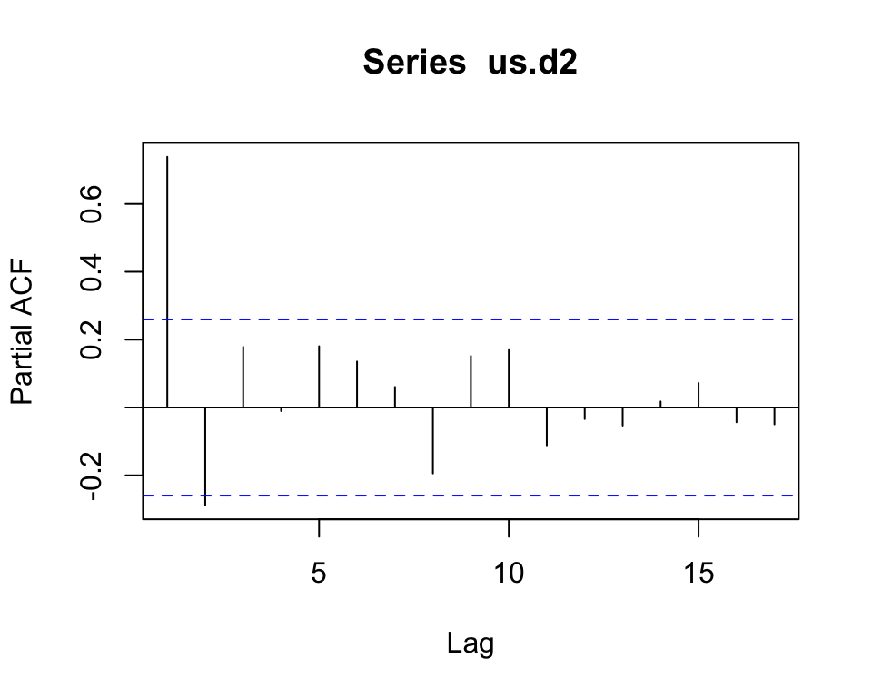

```r
pacf(us.d2)
```

We can replicate this more or less using regression, shown here for the first four lags:

```r
us.d2.l0 <- us.d2[5:(length(us.d2) - 0)]
us.d2.l1 <- us.d2[4:(length(us.d2) - 1)]
us.d2.l2 <- us.d2[3:(length(us.d2) - 2)]
us.d2.l3 <- us.d2[2:(length(us.d2) - 3)]
us.d2.l4 <- us.d2[1:(length(us.d2) - 4)]
stargazer(lm(us.d2.l0 ~ us.d2.l1 + us.d2.l2 + us.d2.l3 + us.d2.l4),
          header = FALSE,
          type = "html")
```

|  | *Dependent variable:* |
| --- | --- |
|  | us.d2.l0 |
| us.d2.l1 | 1.402*** |
|  | (0.149) |
| us.d2.l2 | -1.097*** |
|  | (0.239) |
| us.d2.l3 | 0.629** |
|  | (0.242) |
| us.d2.l4 | -0.127 |
|  | (0.151) |
| Constant | 468.458** |
|  | (213.070) |
| Observations | 53 |
| R<sup>2</sup> | 0.730 |
| Adjusted R<sup>2</sup> | 0.707 |
| Residual Std. Error | 640.498 (df = 48) |
| F Statistic | 32.413*** (df = 4; 48) |
| *Note:* | p<0.1; p<0.05; p<0.01 |

- We see that the first lag is the most significant, and the second is as in the picture fairly strong and negative, the third is barely significative. The fourth and the rest are probably not significant.
- The main effect is determined by the first lag: a shock to $y$ at time $t$ has a direct effect on $y$ at time $t+1$, but mainly affects time $t+2$ via affecting $t+1$. So this may be an AR(1) process (ie, an auto-regressive process where only the first lag affects $Y_t$), or maybe an AR(2) or AR(3) process. We’ll see in a moment.

### Moving average

There is one more wrinkle to the standard time series model. Although it is often the case that $y_t$ is correlated with $y_{t-1}$ and possibly other lags, this can be due a third effect: neither the overall trend, nor to the direct effect of the previous value $y$ on the future value of $y$. Rather, $y$ can be a *moving average* (MA) of its past values. Rather than having a very short memory, where the value $y_t$ is only a function of $y_{t-1}$ and a few more lags, instead $y_t$ is a function of several past lags, all contributing very small amounts.

Essentially, the moving average acts to pull $y$ back towards some value (eg, the natural or long-run GDP growth rate) when it is shifted away from it in the short-run. Thus a good estimate of $y$ in the future will be an average of $y$ in the recent past, even if overall $y$ has no grand trend up or down.

The result, though, is that $y$ again is correlated with its past values. But unlike the auto-correlation model, in the **moving average model (MA)**, the partial auto-correlation (PACF) of Y with its lags is significant even out to many lags, because all those past values influence the overall moving average.

By contrast, while in an AR process the bivariate (not partial) correlation of $y_t$ with past values $y_{t-1}$, $y_{t-2}$, etc, can extend quite a ways into the past (because a shock at time $t$ can still influence $Y_{t+10}$ 10 years down the line via all the intermediate $Y$ values), by contrast for an MA process, usually only the most recent one or two $y_{t-k}$ values are correlated with $Y_t$ (for reasons too complex to go into here).

So you can usually tell whether a process is AR or MA by looking at the partial auto-correlations (the PACF) and looking at the direct, bivariate correlations with past lags (known as the ACF or auto-correlation function). We can plot the ACF with `R` just as we did the PACF:

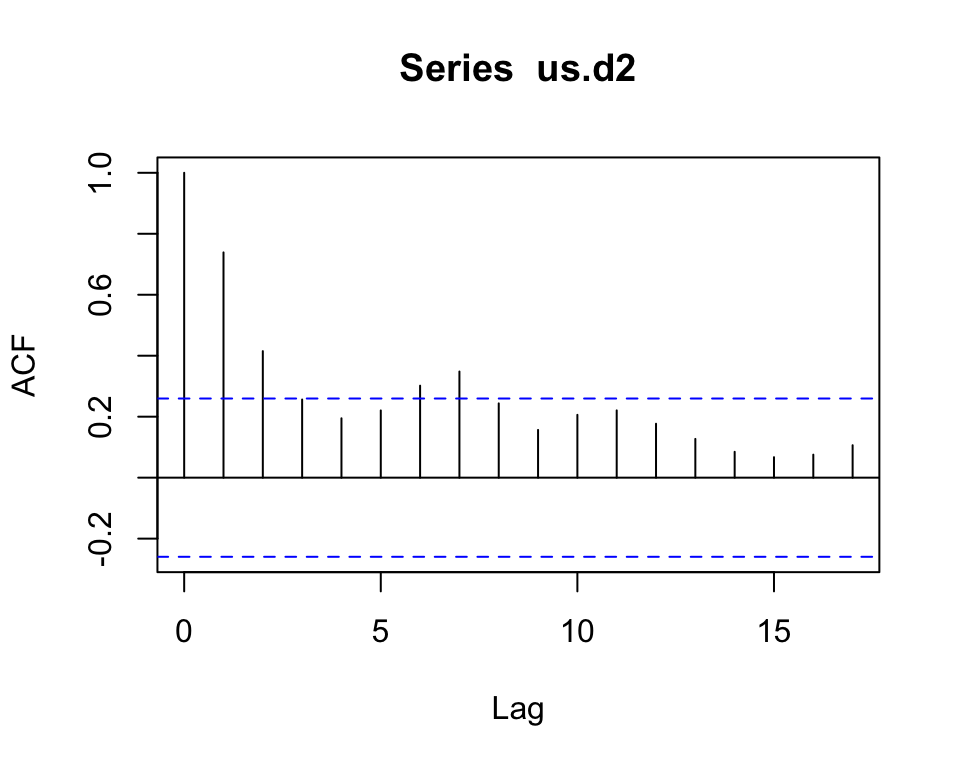

```r
acf(us.d2)
```

Remember, this is the correlation of $y_t$ with $y_{t-1}$ (the first line), $y_t$ with $y_{t-2}$ (the second line), and so on. The PACF, by contrast, was $y_t = y_{t-1} + y_{t-2} + ...$, ie, the correlation with each lag controlling for all the others.

### ARIMA

Of course, as with all models, in the real world we can’t really assess one or the other model – AR or MA – independently. Instead, the data generating process could be a mix of both – a little bit of auto-correlation, where the immediate past values of $y$ influence the next values; and a little bit of moving average, where the long-term history of $y$ tends to have a gradual effect on the future. So to estimate the most appropriate model, we need to try a variety of mixtures of AR and MA, and see which model best fits the data (using, for instance, the Akaike Information Criterion, which is like $R^2$ but generalizes to more kinds of models, not just linear regression).

As usual, R will do our hard work for us. In the `forecast` package is the `auto.arima` function, which will find the best mix of AR and MA. *ARIMA*, of course stands for AR+MA, plus the I, which stands for “integrated” but usually is equivalent to how many differences you have to do to the data first before doing the AR and MA analysis. Thus an ARIMA (1,2,0) model would be a model with 2 differences, an AR(1) process (ie, $Y_t$ is partially correlated with $Y_{t-1}$ but none of the other lags), and a MA(0) (ie, no moving average) part. A (2,1,1) ARIMA process would have an AR(2) component, 1 first-difference, and a MA(1) component.

So what’s the correct per Capita GDP model then? It’s best to run it on the original series, and let the function tell us how many differences we should take:

```r
auto.arima(ts_gdpUS)
```

```
Series: ts_gdpUS
ARIMA(0,2,2)

Coefficients:
          ma1      ma2
      -0.4009  -0.3613
s.e.   0.1159   0.1074

sigma^2 estimated as 292635:  log likelihood=-438.97
AIC=883.94   AICc=884.4   BIC=890.07
```

This appears to be a (0,2,2) ARIMA model: 2 differences (as we found), an AR(0), and a MA(2). While our independent analysis of the AR part found an AR(3), when we include the MA part, we instead get an AR(0) plus an MA(2) – some moving average (ie, this year’s GDP tends to have long-term tendencies it returns to).

Let’s try it with the Spanish and Chinese data

```r
auto.arima(es)
```

```
Series: es
ARIMA(0,1,1) with drift

Coefficients:
         ma1     drift
      0.3876  528.1982
s.e.  0.1472  269.4408

sigma^2 estimated as 2286271:  log likelihood=-505.99
AIC=1017.99   AICc=1018.43   BIC=1024.17
```

```r
auto.arima(ch)
```

```
Series: ch
ARIMA(0,2,0)

sigma^2 estimated as 24401:  log likelihood=-368.8
AIC=739.6   AICc=739.67   BIC=741.64
```

## Independent variables

So what happened to causality? How do we model $y$ as a function of $x$ variables? What causes the US GDP to surge and decline, apart from its own past values? For instance, we might want to include some important economic policy, wars, oil prices, or the GDP of other countries.

It turns out the ARIMA model can easily handle independent variables as well. How that is estimated is beyond the scope of this lesson (see [here](http://robjhyndman.com/hyndsight/arimax/) for more on independent variables, and [here](https://www.otexts.org/fpp/8/7) for more on ARIMA more generally). But the R code is just:

```r
auto.arima(ts_gdpUS, xreg=es)# US ARIMA with Spanish GDP per capita as X
```

```
Series: ts_gdpUS
Regression with ARIMA(0,0,4) errors

Coefficients:
         ma1     ma2     ma3     ma4  intercept    xreg
      1.3809  0.9857  0.9226  0.6189   8877.254  1.2885
s.e.  0.1730  0.2257  0.1767  0.1740   2116.871  0.1288

sigma^2 estimated as 4617690:  log likelihood=-535.14
AIC=1084.29   AICc=1086.48   BIC=1098.83
```

## Prediction

Although we’ve generally been more interested in causal analysis (testing if $x$ causes $y$, and in what way), people are often very interested in time series data for prediction purposes. These models are very easy to extend to prediction, just as we can easily predict a $\hat{y}$ value from some set of $x$ values using the $\beta$ coefficients from a regression. We won’t go into how to do it by hand here, but the `auto.arima` function stores in its output the coefficients to allow the `predict` function to predict future values. Then, we just need to apply the `predict` function to the output of `auto.arima`. For example,

```r
ARIMAus <- auto.arima(gdpUS)
predict(ARIMAus,n.ahead=5)
```

```
$pred
Time Series:
Start = 60
End = 64
Frequency = 1
[1] 64713.97 66472.02 68230.07 69988.12 71746.16

$se
Time Series:
Start = 60
End = 64
Frequency = 1
[1]  540.9575 1020.2573 1424.1862 1813.2492 2202.8883
```

(Of course, we can’t do this with the regression with the X values without know the future X values, or at least predicting them from their own past values.)

And we can plot it using the forecast function:

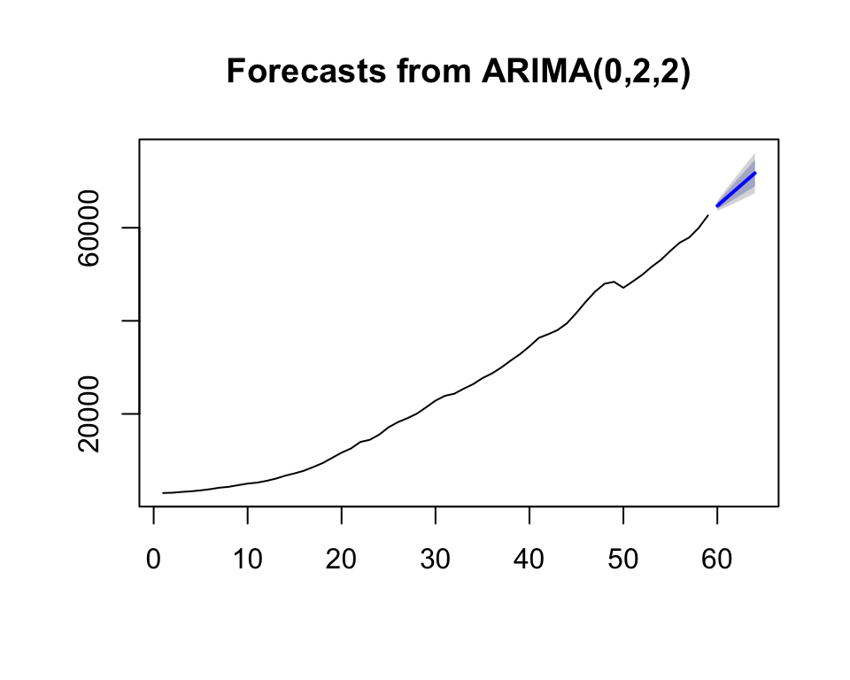

```r
usforecast <- forecast(object = ARIMAus, h = 5)
plot(usforecast)
```

**Time to hit the stock market!**

Not really, be careful using tools that you don’t understand completely. Making accurate forecasts is a very hard - especially with high volatility data -. Let me illustrate this with a short example trying to predict the price of Bitcoins.

### Predictions : Bitcoin price (a warning!)

Let’s imagine that we woke up in November 2017. I don’t know if you remember this time very well, but around that date there was a lot of excitement around the seemingly exponential growth of the price of Bitcoins. A lot of economists (me included) got calls from distant family members and friends asking for advice about investing in Bitcoins.

To understand the context of the problem, first let’s visualize the bitcoin price history up to November 2017,

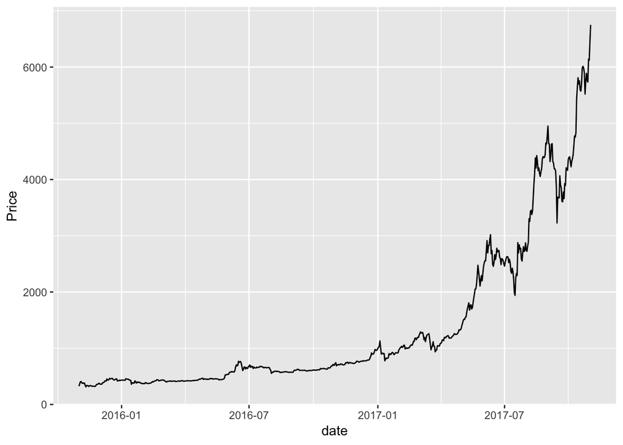

```r
#  install.packages('coindeskr')
library(coindeskr) # Package to get the cryptocurrency data
library(ggplot2)

# loading historical data
bitcoinDB <- get_historic_price(start = "2015-11-01",
      end = "2017-11-01")

# Adding dates to data.frame
bitcoinDB$date <- as.Date(rownames(bitcoinDB))

# Plot using ggplot
ggplot(data = bitcoinDB, aes(y = Price, x = date)) + geom_line()
```

Families asked for loans, regular individual used their savings to buy Bitcoins, parents took money from the savings account for their kids to go to college, a lot of crazy news articles were published about individuals that were literally putting all their money on Bitcoins and other cryptocurrencies – this just added more gas to the fire –.

This was a completely irrational market, individuals were buying Bitcoins just because the price of Bitcoins was increasing – extremely high autocorrelation –. Not because they saw any inherent value in the item – which I’m not saying there is no value in owning Bitcoins, but that’s not the main reason why people were buying Bitcoins in mass, people were buying Bitcoins mainly for speculative reasons –.

Should we buy Bitcoins? What do you think will be the price of Bitcoins a year from today? knowing the answer to that question can be very lucrative. If we find that the returns of buying Bitcoins are greater than what we are getting in our savings account or other safe assets, should we simply go ahead, take the money out of the bank, sell the house, etc. and buy Bitcoins? I mean, we know how to use `R` and are masters of statistics right? nothing can go wrong. Let’s see how we can use the ARIMA model to make a prediction of the price, assuming we are in November of 2017:

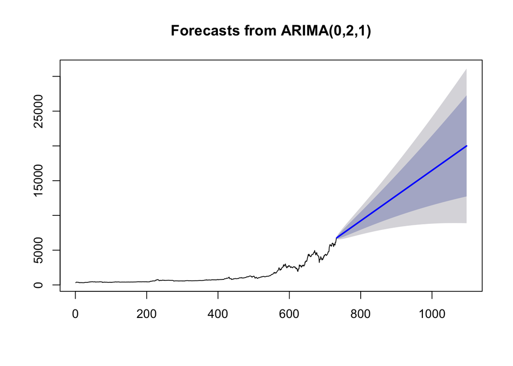

```r
# Making time series
bitcoinPrice <- ts(bitcoinDB$Price , start = 1 ,end= nrow(bitcoinDB))

# Fitting arima model
arimaBitcoin <- auto.arima(bitcoinPrice)

# Making forecasts for January 2018
dateDiff <- round(difftime("2018-11-01", "2017-11-01" , units = c("days")),0)

bitcoinForecast <- forecast(object = arimaBitcoin, h = dateDiff)

# Graph for the yearly forecast
plot(bitcoinForecast)
```

```r
# Actual value at the end of the forecast
bitcoinForecast <- data.frame(fitted = as.numeric(bitcoinForecast$mean))
bitcoinForecast[nrow(bitcoinForecast), ]
```

```
[1] 20000.48
```

Therefore, if we buy a bitcoin today at 6750, we’ll be earning about $\$13,250$ per bitcoin according to this model. Which sounds incredible. That’s a rate of return of $196\%$! This is to good to be true…and it was. But that didn’t stopped a analysts to use this models to advice people to buy more Bitcoins, people that don’t know better. Some may say, even if you use the lower bound of the confidence interval of the predictions, the returns are just outstanding, who are we to argue with the data? Let’s see what actually happened.

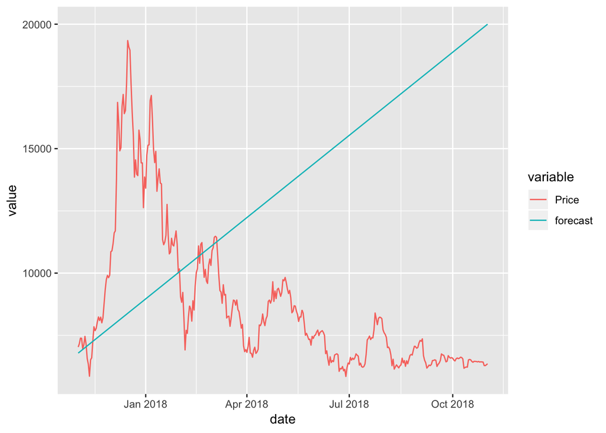

```r
# Let's compare the forecast with the actual data
bitcoinDBActual <- get_historic_price(start = "2017-11-02",
                       end = "2018-11-01")
bitcoinDBActual$date <- as.Date(rownames(bitcoinDBActual))
bitcoinDBActual$forecast <- bitcoinForecast$fitted

# Plotting both series
library(reshape)
df.melted <- melt(bitcoinDBActual, id = "date")

ggplot(data = df.melted, aes(x = date, y = value, color = variable)) +
  geom_line()
```

Oops! This look like an error, but it is not. You would have lost -392 dollars per bitcoin. Which is terrible if you use all your savings.

Time series models are famously **inept** when dealing with *structural changes* as important as the burst of a financial bubble, that’s why we cannot *predict* recessions with a high degree of certainty using regressions or tell what will happen with the economy next year if there are drastic changes in the economic policies. Take this as a warning when using time series model. Simply using the tools introduced here to make decisions/give advice is irresponsible , and, before you go ahead and use them, my advice is that you take a full course on the topic.